# Practical Machine Learning - Course Project

luizsatolo

25 de fevereiro de 2017

## Summary

The goal of this project is to predict the manner in which 6 participants did an exercise, represented by the variable “classe”.

## Exploratory data analysis

The original training data set has 160 variables and 19622 observations. But there’s an important amount of missing values. Instead of using any technique imputing values, as it would introduce more error in the predictions, the strategy adopted was to ommit the missing values.

```r
library(caret)
```

```r
library(ggplot2)
trainData<-read.csv("pml-training.csv")
testData<-read.csv("pml-testing.csv")
trainData<-na.omit(trainData)
dim(trainData)
```

```
## [1] 406 160
```

## Cross validation

The method used for cross validation was “leave one out” (LOOCV), passed as an argument to the trainControl function.

```r
set.seed(1283)
crossValidation <- trainControl(method="LOOCV")
```

## Model

Although there’re 160 variables to be chosen, many of them presented no variation among the participants and, therefore, couldn’t be used to fit the model. The model with the variables selected for prediction is:

```r
set.seed(1283)
model1<-train(classe~roll_belt+pitch_belt+yaw_belt+gyros_belt_x+gyros_belt_y+gyros_belt_z+accel_belt_x+accel_belt_y+accel_belt_z+magnet_belt_x+magnet_belt_y+magnet_belt_z+roll_arm+pitch_arm+yaw_arm+gyros_arm_x+gyros_arm_y+gyros_arm_z+accel_arm_x+accel_arm_y+accel_arm_z+magnet_arm_x+magnet_arm_y+magnet_arm_z+roll_dumbbell+pitch_dumbbell+yaw_dumbbell+gyros_dumbbell_x+gyros_dumbbell_y+gyros_dumbbell_z+accel_dumbbell_x+accel_dumbbell_y+accel_dumbbell_z+magnet_dumbbell_x+magnet_dumbbell_y+magnet_dumbbell_z+roll_forearm+pitch_forearm+yaw_forearm,method="rf",data=trainData,trControl=crossValidation,prox=TRUE)
```

The method used to train the model was random forest, and the accuracy was 78%.

## Out of sample error

As the values of the variable classe weren’t available for the testing data set, the out of sample error couldn’t be estimated, but it’s expected to be higher (and hopefully close) to the inside of sample error.

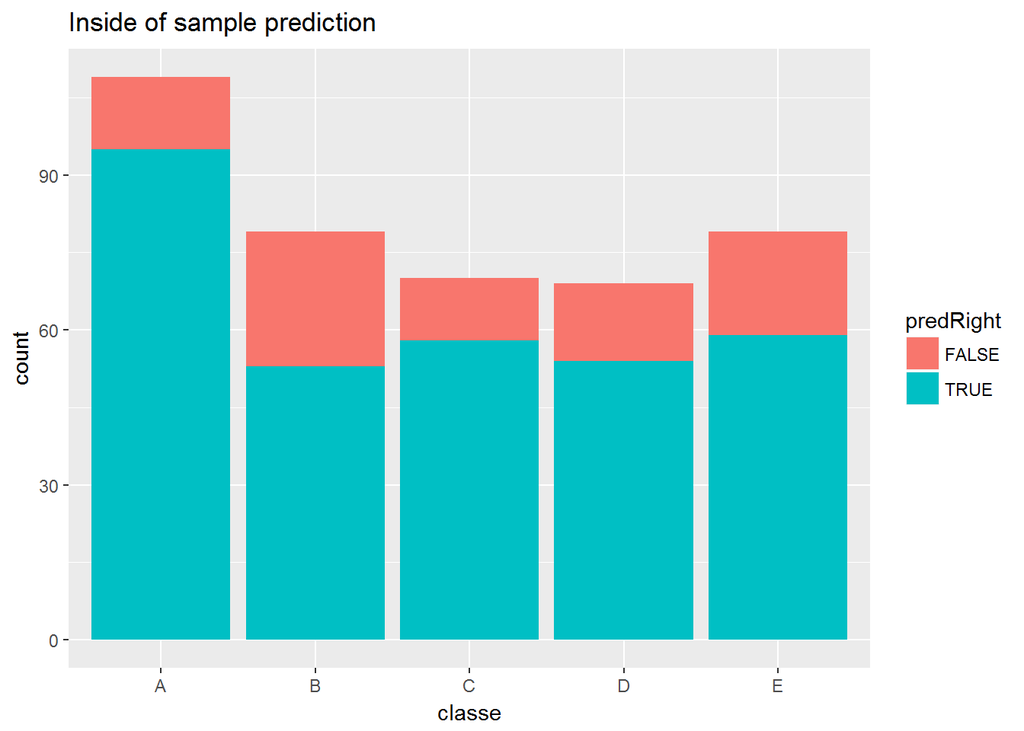

```r
trainData$predRight<-model1$finalModel$predicted==trainData$classe
qplot(classe, fill=predRight, data=trainData, main="Inside of sample prediction")
```

```r
confusionMatrix(model1$finalModel$predicted,trainData$classe)
```

```
## Confusion Matrix and Statistics
##
##           Reference
## Prediction  A  B  C  D  E
##          A 95  9  6  3  0
##          B  7 53  4  2  9
##          C  2 10 58  8  7
##          D  5  6  2 54  4
##          E  0  1  0  2 59
##
## Overall Statistics
##
##                Accuracy : 0.7857
##                  95% CI : (0.7426, 0.8247)
##     No Information Rate : 0.2685
##     P-Value [Acc > NIR] : < 2.2e-16
##
##                   Kappa : 0.7301
##  Mcnemar's Test P-Value : NA
##
## Statistics by Class:
##
##                      Class: A Class: B Class: C Class: D Class: E
## Sensitivity            0.8716   0.6709   0.8286   0.7826   0.7468
## Specificity            0.9394   0.9327   0.9196   0.9496   0.9908
## Pos Pred Value         0.8407   0.7067   0.6824   0.7606   0.9516
## Neg Pred Value         0.9522   0.9215   0.9626   0.9552   0.9419
## Prevalence             0.2685   0.1946   0.1724   0.1700   0.1946
## Detection Rate         0.2340   0.1305   0.1429   0.1330   0.1453
## Detection Prevalence   0.2783   0.1847   0.2094   0.1749   0.1527
## Balanced Accuracy      0.9055   0.8018   0.8741   0.8661   0.8688
```

As the accuracy of the inside of sample estimation is 78%, its expected error is of 22%. Then, the out of sample error is expected to be larger than 22%. The out of sample prediction using the testing set is given by:

```r
predict(model1,newdata=testData)
```

[output not shown]